# Project: no show appointments Dataset

## Table of Contents

- Introduction
- Data Wrangling
- Exploratory Data Analysis
- Conclusions

## Introduction

##### About Dataset

- his dataset collects information from 100k medical appointments in Brazil with details such as - age, gender, no_show, ScheduledDay, appointmentday, etc.

main question:

- is focused on the question of whether or not patients show up for their appointment.

##### questions

- Does the attendance rate differ by gender?
- Does interest in attending appointments increase with different age groups?
- Does sending a sms to the patient increase the attendance rate?
- Does the attendance rate differ from one day to another and which days the attendance rate is the highest possible?
- Does Scholarship affect attendance?
- Does the percentage of people with high blood pressure affect the attendance rate?
- Does the percentage of people with Diabetic affect the attendance rate?e
- Does the percentage of people with Diabetic affect the attendance rate?e
- Does the percentage of people with alcoholism affect the attendance rate?
- Does Handicap Ratio Affect Attendance?
- Does the attendance rate differ from one Neighbourhood to another and which Neighbourhood the attendance rate is the highest possible?

##### import packages

```python
import pandas as pd
import numpy as np
import matplotlib.pyplot as plt
import seaborn as sns
%matplotlib inline
```

## Data Wrangling

### General Properties

#### Data Gathering

```python
# Load data
df=pd.read_csv('noshowappointments-kagglev2-may-2016.csv')
```

#### Data Acessing

```python
# Display out a few lines.
df.head(5)
```

|  | PatientId | AppointmentID | Gender | ScheduledDay | AppointmentDay | Age | Neighbourhood | Scholarship | Hipertension | Diabetes | Alcoholism | Handcap | SMS_received | No-show |
| --- | --- | --- | --- | --- | --- | --- | --- | --- | --- | --- | --- | --- | --- | --- |
| 0 | 2.987250e+13 | 5642903 | F | 2016-04-29T18:38:08Z | 2016-04-29T00:00:00Z | 62 | JARDIM DA PENHA | 0 | 1 | 0 | 0 | 0 | 0 | No |
| 1 | 5.589978e+14 | 5642503 | M | 2016-04-29T16:08:27Z | 2016-04-29T00:00:00Z | 56 | JARDIM DA PENHA | 0 | 0 | 0 | 0 | 0 | 0 | No |
| 2 | 4.262962e+12 | 5642549 | F | 2016-04-29T16:19:04Z | 2016-04-29T00:00:00Z | 62 | MATA DA PRAIA | 0 | 0 | 0 | 0 | 0 | 0 | No |
| 3 | 8.679512e+11 | 5642828 | F | 2016-04-29T17:29:31Z | 2016-04-29T00:00:00Z | 8 | PONTAL DE CAMBURI | 0 | 0 | 0 | 0 | 0 | 0 | No |
| 4 | 8.841186e+12 | 5642494 | F | 2016-04-29T16:07:23Z | 2016-04-29T00:00:00Z | 56 | JARDIM DA PENHA | 0 | 1 | 1 | 0 | 0 | 0 | No |

```python
df.shape
```

```
(110527, 14)
```

```python
# used to check missing values and Data types
df.info()
```

```
<class 'pandas.core.frame.DataFrame'>
RangeIndex: 110527 entries, 0 to 110526
Data columns (total 14 columns):
 #   Column          Non-Null Count   Dtype
---  ------          --------------   -----
 0   PatientId       110527 non-null  float64
 1   AppointmentID   110527 non-null  int64
 2   Gender          110527 non-null  object
 3   ScheduledDay    110527 non-null  object
 4   AppointmentDay  110527 non-null  object
 5   Age             110527 non-null  int64
 6   Neighbourhood   110527 non-null  object
 7   Scholarship     110527 non-null  int64
 8   Hipertension    110527 non-null  int64
 9   Diabetes        110527 non-null  int64
 10  Alcoholism      110527 non-null  int64
 11  Handcap         110527 non-null  int64
 12  SMS_received    110527 non-null  int64
 13  No-show         110527 non-null  object
dtypes: float64(1), int64(8), object(5)
memory usage: 11.8+ MB
```

```python
# Display brief statistics about data set
# and show distribution of data set
# Through the function, he discovered a false distribution in age column
df.describe()
```

|  | PatientId | AppointmentID | Age | Scholarship | Hipertension | Diabetes | Alcoholism | Handcap | SMS_received |
| --- | --- | --- | --- | --- | --- | --- | --- | --- | --- |
| count | 1.105270e+05 | 1.105270e+05 | 110527.000000 | 110527.000000 | 110527.000000 | 110527.000000 | 110527.000000 | 110527.000000 | 110527.000000 |
| mean | 1.474963e+14 | 5.675305e+06 | 37.088874 | 0.098266 | 0.197246 | 0.071865 | 0.030400 | 0.022248 | 0.321026 |
| std | 2.560949e+14 | 7.129575e+04 | 23.110205 | 0.297675 | 0.397921 | 0.258265 | 0.171686 | 0.161543 | 0.466873 |
| min | 3.921784e+04 | 5.030230e+06 | -1.000000 | 0.000000 | 0.000000 | 0.000000 | 0.000000 | 0.000000 | 0.000000 |
| 25% | 4.172614e+12 | 5.640286e+06 | 18.000000 | 0.000000 | 0.000000 | 0.000000 | 0.000000 | 0.000000 | 0.000000 |
| 50% | 3.173184e+13 | 5.680573e+06 | 37.000000 | 0.000000 | 0.000000 | 0.000000 | 0.000000 | 0.000000 | 0.000000 |
| 75% | 9.439172e+13 | 5.725524e+06 | 55.000000 | 0.000000 | 0.000000 | 0.000000 | 0.000000 | 0.000000 | 1.000000 |
| max | 9.999816e+14 | 5.790484e+06 | 115.000000 | 1.000000 | 1.000000 | 1.000000 | 1.000000 | 4.000000 | 1.000000 |

```python
# check age value
df['Age'].value_counts()
```

```
 0      3539
 1      2273
 52     1746
 49     1652
 53     1651
        ...
 115       5
 100       4
 102       2
 99        1
-1         1
Name: Age, Length: 104, dtype: int64
```

```python
# after check if find illogical value  age=-1
x=df[df['Age']<0].index
# drop illogical value
df.drop(x,axis=0,inplace=True)
```

```python
# check again to sure drop illogical value
df[df['Age']<0]
```

|  | PatientId | AppointmentID | Gender | ScheduledDay | AppointmentDay | Age | Neighbourhood | Scholarship | Hipertension | Diabetes | Alcoholism | Handcap | SMS_received | No-show |
| --- | --- | --- | --- | --- | --- | --- | --- | --- | --- | --- | --- | --- | --- | --- |

```python
# check duplicated rows
df.duplicated().sum()
```

```
0
```

```python
# check missing values
df.isnull().sum()
```

```
PatientId         0
AppointmentID     0
Gender            0
ScheduledDay      0
AppointmentDay    0
Age               0
Neighbourhood     0
Scholarship       0
Hipertension      0
Diabetes          0
Alcoholism        0
Handcap           0
SMS_received      0
No-show           0
dtype: int64
```

```python
# check number of unique in each column
unique_list=[]
for i in df.columns:
    x=df[i].nunique()
    unique_list.append({i:x})

unique_list
```

```
[{'PatientId': 62298},
 {'AppointmentID': 110526},
 {'Gender': 2},
 {'ScheduledDay': 103548},
 {'AppointmentDay': 27},
 {'Age': 103},
 {'Neighbourhood': 81},
 {'Scholarship': 2},
 {'Hipertension': 2},
 {'Diabetes': 2},
 {'Alcoholism': 2},
 {'Handcap': 5},
 {'SMS_received': 2},
 {'No-show': 2}]
```

##### result data access process

- drop unimportant or unused columns
- not have missing values
- not have duplicated data
- 2 wrong data type
- rename 1 colunm

drop unimportant or unused columns

```python
df.drop(['PatientId','AppointmentID'],axis=1,inplace=True)
df.head(1)
```

|  | Gender | ScheduledDay | AppointmentDay | Age | Neighbourhood | Scholarship | Hipertension | Diabetes | Alcoholism | Handcap | SMS_received | No-show |
| --- | --- | --- | --- | --- | --- | --- | --- | --- | --- | --- | --- | --- |
| 0 | F | 2016-04-29T18:38:08Z | 2016-04-29T00:00:00Z | 62 | JARDIM DA PENHA | 0 | 1 | 0 | 0 | 0 | 0 | No |

```python
df.shape
```

```
(110526, 12)
```

```python
df.info()
```

```
<class 'pandas.core.frame.DataFrame'>
Int64Index: 110526 entries, 0 to 110526
Data columns (total 12 columns):
 #   Column          Non-Null Count   Dtype
---  ------          --------------   -----
 0   Gender          110526 non-null  object
 1   ScheduledDay    110526 non-null  object
 2   AppointmentDay  110526 non-null  object
 3   Age             110526 non-null  int64
 4   Neighbourhood   110526 non-null  object
 5   Scholarship     110526 non-null  int64
 6   Hipertension    110526 non-null  int64
 7   Diabetes        110526 non-null  int64
 8   Alcoholism      110526 non-null  int64
 9   Handcap         110526 non-null  int64
 10  SMS_received    110526 non-null  int64
 11  No-show         110526 non-null  object
dtypes: int64(7), object(5)
memory usage: 11.0+ MB
```

change data type

```python
df['ScheduledDay']=pd.to_datetime(df['ScheduledDay'])
df['AppointmentDay']=pd.to_datetime(df['AppointmentDay'])
```

```python
df.dtypes
```

```
Gender                         object
ScheduledDay      datetime64[ns, UTC]
AppointmentDay    datetime64[ns, UTC]
Age                             int64
Neighbourhood                  object
Scholarship                     int64
Hipertension                    int64
Diabetes                        int64
Alcoholism                      int64
Handcap                         int64
SMS_received                    int64
No-show                        object
dtype: object
```

rename column

```python
df.rename(columns={"No-show":'No_show'},inplace=True)
```

```python
df.head(1)
```

|  | Gender | ScheduledDay | AppointmentDay | Age | Neighbourhood | Scholarship | Hipertension | Diabetes | Alcoholism | Handcap | SMS_received | No_show |
| --- | --- | --- | --- | --- | --- | --- | --- | --- | --- | --- | --- | --- |
| 0 | F | 2016-04-29 18:38:08+00:00 | 2016-04-29 00:00:00+00:00 | 62 | JARDIM DA PENHA | 0 | 1 | 0 | 0 | 0 | 0 | No |

## Exploratory Data Analysis

##### Two functions to extract data and ploting

```python
def extract_data(x):
    """
    function used to extract data from each column

    inputs:
       (str) x: name of column

    return:
       (float) x_show: number of have(x) that show
       (float) x_noshow: number of  not have(x) that show
       (float) not_have_x_show: number of have(x) that not show
       (float) not_have_x_noshow: number of not have(x) that not show

    """
    total_x_count_seprated=dict(df.groupby(['No_show'])[x].value_counts())
    total_x_count=dict(df[x].value_counts())
    if x!="Gender":
        x_show=total_x_count_seprated[('No',0)] / total_x_count[0]
        not_have_x_show=total_x_count_seprated[('No',1)] / total_x_count[1]


        x_noshow=total_x_count_seprated[('Yes',0)] / total_x_count[0]
        not_have_x_noshow=total_x_count_seprated[('Yes',1)] / total_x_count[1]
    else:
        x_show=total_x_count_seprated[('No','F')] / total_x_count['F']
        not_have_x_show=total_x_count_seprated[('No','M')] / total_x_count['M']


        x_noshow=total_x_count_seprated[('Yes','F')] / total_x_count['F']
        not_have_x_noshow=total_x_count_seprated[('Yes','M')] / total_x_count['M']

    return(x_show,x_noshow,not_have_x_show,not_have_x_noshow)
```

```python
def draw_plot(x):
    """
    fuction to Draw plot of extracted from column

    input:
        (str) x: name of column

    """
    barWidth = 0.1
    extract_values=extract_data(x)
    fig = plt.subplots(figsize =(5, 5))
    show = [extract_values[0],extract_values[1]]
    not_show = [extract_values[2],extract_values[3]]


    br1 = np.arange(len(show))
    br2 = [x + barWidth for x in br1]

    plt.bar(br1, show, color ='#9fb300', width = barWidth,
        edgecolor ='grey', label =x)
    plt.bar(br2, not_show, color ='#0af', width = barWidth,
        edgecolor ='grey', label =' Not Have {0}'.format(x))


# Adding Xticks
    plt.xlabel(x, fontweight ='bold', fontsize = 10)
    plt.ylabel('attendance', fontweight ='bold', fontsize = 10)
    plt.xticks([0,1],
        ['Show', 'Not Show'])
    plt.title('Proportion of  attendance by {}'.format(x))

    plt.legend()
    plt.show()
```

### Research Question 1 (Does the attendance rate differ depending on the Gender)

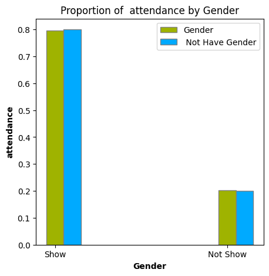

```python
draw_plot("Gender")
```

In the last figure, each column has been used from (Gender, no_show) I used the grouppy function to extract the females and males it attends and counts the number of each As well as extracting the number of females and males not attending and dividing each of them by the total number of females and males and using bar plot to present them

### Research Question 2 (Does interest in attending appointments increase with different age groups?)

```python
df['Age'].describe()
```

```
count    110526.000000
mean         37.089219
std          23.110026
min           0.000000
25%          18.000000
50%          37.000000
75%          55.000000
max         115.000000
Name: Age, dtype: float64
```

```python
age_level=dict(df['Age'].describe())
```

create new column that divided data into four category

```python
bin_edges = [age_level['min'],age_level['25%'],age_level['50%'],age_level['75%'],age_level['max'] ]
bin_names = ['awkward age' ,'Youth','half-life' ,'aged']
df['age_levels'] = pd.cut(df['Age'], bin_edges, labels=bin_names)
```

```python
df['age_levels'].value_counts()
```

```
aged           27504
Youth          27250
half-life      26906
awkward age    25327
Name: age_levels, dtype: int64
```

extract count of each category that attends and not attends

```python
age_level_show=dict(df[df['No_show']=='No'].groupby('No_show')['age_levels'].value_counts())
age_level_noshow=dict(df[df['No_show']=='Yes'].groupby('No_show')['age_levels'].value_counts())
age_level_show
```

```
{('No', 'aged'): 23201,
 ('No', 'half-life'): 21651,
 ('No', 'Youth'): 20836,
 ('No', 'awkward age'): 19619}
```

total count of each category

```python
total_age_levels_count=dict(df['age_levels'].value_counts())
total_age_levels_count
```

```
{'aged': 27504, 'Youth': 27250, 'half-life': 26906, 'awkward age': 25327}
```

extract Prospection for each catogrical that attends

```python
prop_aged_show=age_level_show[('No','aged')]/total_age_levels_count['aged']
prop_half_life_show=age_level_show[('No','half-life')]/total_age_levels_count['half-life']
prop_youth_show=age_level_show[('No','Youth')]/total_age_levels_count['Youth']
prop_awkward_age_show=age_level_show[('No','awkward age')]/total_age_levels_count['awkward age']
```

extract Prospection for each catogrical that not attends

```python
prop_aged_noshow=age_level_noshow[('Yes','aged')]/total_age_levels_count['aged']
prop_half_life_noshow=age_level_noshow[('Yes','half-life')]/total_age_levels_count['half-life']
prop_youth_noshow=age_level_noshow[('Yes','Youth')]/total_age_levels_count['Youth']
prop_awkward_age_noshow=age_level_noshow[('Yes','awkward age')]/total_age_levels_count['awkward age']
```

using bar plot to represent

[figure not shown]

```python
barWidth = 0.1

fig = plt.subplots(figsize =(5, 5))
d1 = [prop_aged_show,prop_aged_noshow]
d2 = [prop_half_life_show,prop_half_life_noshow]
d3 = [prop_youth_show,prop_youth_noshow]
d4 = [prop_awkward_age_show,prop_awkward_age_noshow]

br1 = np.arange(len(d1))
br2 = [x + barWidth for x in br1]
br3 = [x + barWidth for x in br2]
br4 = [x + barWidth for x in br3]



plt.bar(br1, d1, color ='#52170b', width = barWidth,
        edgecolor ='grey', label ='aged')
plt.bar(br2, d2, color ='#7a1b0c', width = barWidth,
        edgecolor ='grey', label ='half_life')
plt.bar(br3, d3, color ='#a51b0b', width = barWidth,
        edgecolor ='grey', label ='youth')
plt.bar(br4, d4, color ='#d11507', width = barWidth,
        edgecolor ='grey', label ='awkward_age')



# Adding Xticks
plt.xlabel('Gender', fontweight ='bold', fontsize = 10)
plt.ylabel('attendance', fontweight ='bold', fontsize = 10)
plt.xticks([0,1],
        ['Show', 'Not Show'])

plt.legend()
plt.show()
```

In the last figure, each column has been used from (age,age_levels, no_show) used describe and cut funtion to create new column divided into four categories(aged,half-live,youth,amkward_age) I used the grouppy function to extract the count of each categories that attends and not attends and dividing each of them by the total number of categories in both (attends,not attends) and using bar plot to present them

### Research Question 3 (Does sending a sms to the patient increase the attendance rate?)

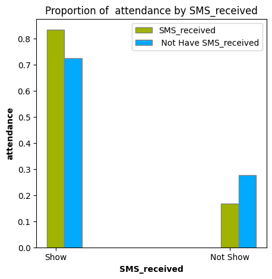

```python
draw_plot('SMS_received')
```

In the last figure, each column has been used from (sms_received, no_show) I used the grouppy function to extract count of people received sms and not received append to depending on no_show column and dividing each of them by the total number of sms (recived ,not recived) and using bar plot to present them

### Research Question 4 (Does the attendance rate differ from one day to another and which days the attendance rate is the highest possible?)

```python
df['day']=df['AppointmentDay'].dt.day_of_week
df.groupby('No_show')['day'].value_counts()
```

```
No_show  day
No       2      20774
         1      20488
         0      18024
         4      14982
         3      13909
         5         30
Yes      1       5152
         2       5093
         0       4690
         4       4037
         3       3338
         5          9
Name: day, dtype: int64
```

create new coulmns which convert days from numbers to week name

```python
day_name=[]
for i in df['day']:
    if i == 0:
        day_name.append("sunday")
    elif i== 1:
        day_name.append("monday")
    elif i==2:
        day_name.append("tuesday")
    elif i==3:
        day_name.append("wednesday")
    elif i==4:
        day_name.append("thursday")
    elif i==5:
        day_name.append('friday')
    else:
        day_name.append('saturday')

df["day_name"]=day_name
```

[figure not shown]

```python
locations=np.arange(0,12,1)
colors=[ 'Orange','gray','red','Green','Yellow','Pink','Orange','gray','red','Green','Yellow','Pink']
fig = plt.subplots(figsize =(15, 5))
plt.bar(locations,df.groupby("No_show")["day_name"].value_counts(),color=colors)
plt.xlabel("Week_Day", fontweight ='bold', fontsize = 10)
plt.ylabel('attendance', fontweight ='bold', fontsize = 10)
plt.xticks(locations,
            labels=['sunday', 'monday', 'tuesday', 'wednesday','thursday', 'friday','sunday',
                  'monday', 'tuesday', 'wednesday','thursday', 'friday'])
plt.title('count of attends-not attents people in each day')
```

### Research Question 5 (Does Scholarship affect attendance??)

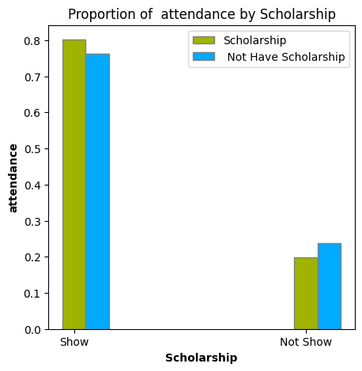

```python
draw_plot('Scholarship')
```

In the last figure, each column has been used from (scholarship, no_show) I used the grouppy function to extract count of people (have,not have) scholarship it (attends,not attends) spareted by no_show column and dividing each of them by the total people have or not and using bar plot to present them

### Research Question 6 (Does the percentage of people with high blood pressure affect the attendance rate?)

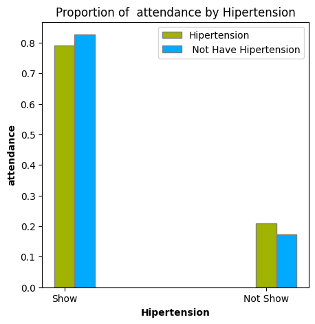

```python
draw_plot('Hipertension')
```

In the last figure, each column has been used from (Hipertension, no_show) I used the grouppy function to extract count of people (have,not have) Hipertension it (attends,not attends) spareted by no_show column and dividing each of them by the total people have or not and using bar plot to present them

### Research Question 7 (Does the percentage of people with Diabetic affect the attendance rate?)

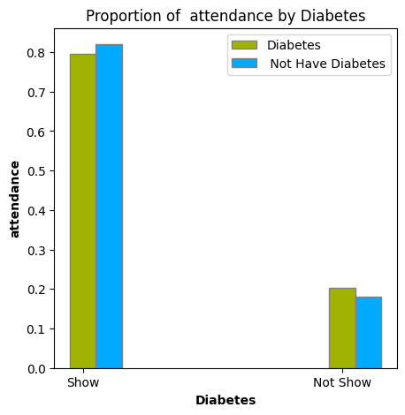

```python
draw_plot('Diabetes')
```

In the last figure, each column has been used from (Diabetes, no_show) I used the grouppy function to extract count of people (have,not have) Diabetes it (attends,not attends) spareted by no_show column and dividing each of them by the total people have or not and using bar plot to present them

### Research Question 8 (Does the percentage of people with alcoholism affect the attendance rate?)

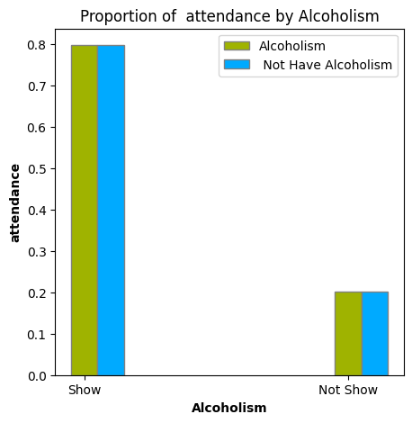

```python
draw_plot('Alcoholism')
```

In the last figure, each column has been used from (Alcohlism, no_show) I used the grouppy function to extract count of people (have,not have) Alcohlism it (attends,not attends) spareted by no_show column and dividing each of them by the total people have or not and using bar plot to present them

### Research Question 9 (Does Handicap Ratio Affect Attendance?)

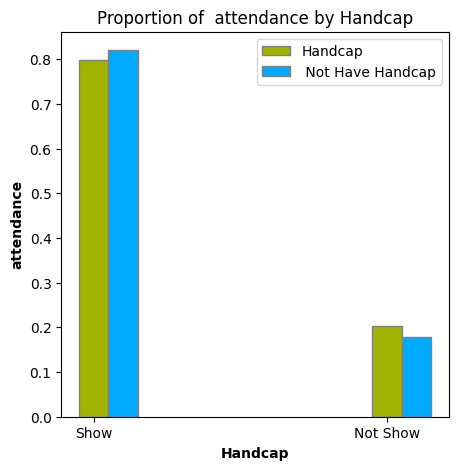

```python
draw_plot('Handcap')
```

In the last figure, each column has been used from (Handcap, no_show) I used the grouppy function to extract count of people (have,not have) Handcap it (attends,not attends) spareted by no_show column and dividing each of them by the total people have or not and using bar plot to present them

### Research Question 10 (Does the attendance rate differ from one Neighbourhood to another and which Neighbourhood the attendance rate is the highest possible?)

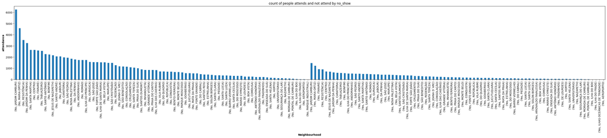

```python
df['Neighbourhood'].value_counts()
df.groupby('No_show')["Neighbourhood"].value_counts().plot(kind='bar',figsize=(40,5))
plt.xlabel('Neighbourhood', fontweight ='bold', fontsize = 10)
plt.ylabel('attendance', fontweight ='bold', fontsize = 10)
plt.title('count of people attends and not attend by no_show')
```

In the last figure, each column has been used from (Neighbourhood, no_show) I used the grouppy function to extract count of people (attends,not attends) spareted by no_show column and using bar plot to present them

## Conclusions

Limitations: There are a couple of limitations with our data:

Most of our variables are categorical, which does not allow for a high level of statistical method that can be used to provide correlations etc Cannot show strong correlations between factors since most of our data is categorical.